# DB-Homework-5

Derek Bornath

05/03/2020

##1)Work through the regression tree example 1 provided on My Learning Space.

##2) Now let’s build a regression tree to help predict crime rate according to some of the predictor variables found in crimedata.csv. Make sure to include expenditures on police in each state (ExpenditureYear) as well as population size of state (StateSize) and the number of low income families in each state (BelowWage). Also, include at least 3 other variables you think might be important predictors of crime rates.

```r
library(rpart)
library(rpart.plot)
CurrentCrime=read.csv('crimedata.csv')

summary(CurrentCrime)
```

```
##    CrimeRate         Youth          Southern        Education
##  Min.   : 45.5   Min.   :119.0   Min.   :0.0000   Min.   :10.00
##  1st Qu.: 82.7   1st Qu.:130.0   1st Qu.:0.0000   1st Qu.:11.55
##  Median :103.0   Median :136.0   Median :0.0000   Median :12.40
##  Mean   :102.8   Mean   :138.6   Mean   :0.3404   Mean   :12.39
##  3rd Qu.:120.7   3rd Qu.:146.0   3rd Qu.:1.0000   3rd Qu.:13.20
##  Max.   :161.8   Max.   :177.0   Max.   :1.0000   Max.   :15.10
##  ExpenditureYear  LabourForce        Males          MoreMales
##  Min.   : 45.0   Min.   :480.0   Min.   : 934.0   Min.   :0.0000
##  1st Qu.: 62.5   1st Qu.:530.5   1st Qu.: 964.5   1st Qu.:0.0000
##  Median : 78.0   Median :560.0   Median : 977.0   Median :0.0000
##  Mean   : 85.0   Mean   :561.2   Mean   : 983.0   Mean   :0.1915
##  3rd Qu.:104.5   3rd Qu.:593.0   3rd Qu.: 992.0   3rd Qu.:0.0000
##  Max.   :166.0   Max.   :641.0   Max.   :1071.0   Max.   :1.0000
##    StateSize      YouthUnemployment MatureUnemployment HighYouthUnemploy
##  Min.   :  3.00   Min.   : 70.00    Min.   :20.00      Min.   :0.0000
##  1st Qu.: 10.00   1st Qu.: 80.50    1st Qu.:27.50      1st Qu.:0.0000
##  Median : 25.00   Median : 92.00    Median :34.00      Median :0.0000
##  Mean   : 36.62   Mean   : 95.47    Mean   :33.98      Mean   :0.3191
##  3rd Qu.: 41.50   3rd Qu.:104.00    3rd Qu.:38.50      3rd Qu.:1.0000
##  Max.   :168.00   Max.   :142.00    Max.   :58.00      Max.   :1.0000
##       Wage         BelowWage
##  Min.   :288.0   Min.   :126.0
##  1st Qu.:459.5   1st Qu.:165.5
##  Median :537.0   Median :176.0
##  Mean   :525.4   Mean   :194.0
##  3rd Qu.:591.5   3rd Qu.:227.5
##  Max.   :689.0   Max.   :276.0
```

```r
set.seed(365)
train=sample(x = nrow(CurrentCrime), size = 40, replace = FALSE)
train.data= CurrentCrime[sample(x=nrow(CurrentCrime),size=40, replace=FALSE),]
```

##3) Print summary of regression tree results. Which variables were most important in your tree?

```r
m.rpart=rpart(CrimeRate~Youth+Education+YouthUnemployment+BelowWage+StateSize+Males+LabourForce+HighYouthUnemploy+ExpenditureYear, data=train.data, cp=10^(-6))

summary(m.rpart)
```

```
## Call:
## rpart(formula = CrimeRate ~ Youth + Education + YouthUnemployment +
##     BelowWage + StateSize + Males + LabourForce + HighYouthUnemploy +
##     ExpenditureYear, data = train.data, cp = 10^(-6))
##   n= 40
##
##          CP nsplit rel error    xerror      xstd
## 1 0.3474675      0 1.0000000 1.0332700 0.1959034
## 2 0.1679338      1 0.6525325 0.7966242 0.1440979
## 3 0.0000010      2 0.4845987 0.7997127 0.1444906
##
## Variable importance
##   ExpenditureYear             Youth         BelowWage         Education
##                25                21                18                11
##         StateSize YouthUnemployment             Males
##                11                11                 3
##
## Node number 1: 40 observations,    complexity param=0.3474675
##   mean=100.3725, MSE=735.4135
##   left son=2 (18 obs) right son=3 (22 obs)
##   Primary splits:
##       ExpenditureYear   < 71.5  to the left,  improve=0.34746750, (0 missing)
##       LabourForce       < 541   to the left,  improve=0.13611790, (0 missing)
##       Males             < 997   to the left,  improve=0.10162430, (0 missing)
##       BelowWage         < 244   to the right, improve=0.06969058, (0 missing)
##       YouthUnemployment < 80.5  to the left,  improve=0.06617537, (0 missing)
##   Surrogate splits:
##       BelowWage         < 230.5 to the right, agree=0.800, adj=0.556, (0 split)
##       Youth             < 132.5 to the right, agree=0.700, adj=0.333, (0 split)
##       Education         < 11.55 to the left,  agree=0.700, adj=0.333, (0 split)
##       YouthUnemployment < 77.5  to the left,  agree=0.675, adj=0.278, (0 split)
##       StateSize         < 39.5  to the left,  agree=0.675, adj=0.278, (0 split)
##
## Node number 2: 18 observations
##   mean=82.7, MSE=353.7044
##
## Node number 3: 22 observations,    complexity param=0.1679338
##   mean=114.8318, MSE=583.1167
##   left son=6 (9 obs) right son=7 (13 obs)
##   Primary splits:
##       Youth             < 130.5 to the left,  improve=0.3850806, (0 missing)
##       StateSize         < 21.5  to the right, improve=0.2718512, (0 missing)
##       YouthUnemployment < 85.5  to the left,  improve=0.1308829, (0 missing)
##       ExpenditureYear   < 107.5 to the left,  improve=0.1274820, (0 missing)
##       BelowWage         < 173   to the left,  improve=0.1181585, (0 missing)
##   Surrogate splits:
##       YouthUnemployment < 96.5  to the right, agree=0.727, adj=0.333, (0 split)
##       BelowWage         < 171.5 to the left,  agree=0.727, adj=0.333, (0 split)
##       StateSize         < 50.5  to the right, agree=0.727, adj=0.333, (0 split)
##       Education         < 12.4  to the right, agree=0.682, adj=0.222, (0 split)
##       Males             < 950.5 to the left,  agree=0.682, adj=0.222, (0 split)
##
## Node number 6: 9 observations
##   mean=96.82222, MSE=375.5062
##
## Node number 7: 13 observations
##   mean=127.3, MSE=346.8446
```

#The most important variables would be ExpenditureYear, Youth, and BelowWage. The next teir variables would be Education, StateSize, and YouthUnemployment

##4)Using the rpart.plot function, plot your regression tree. Provide a brief description in words of what the diagram is telling you.

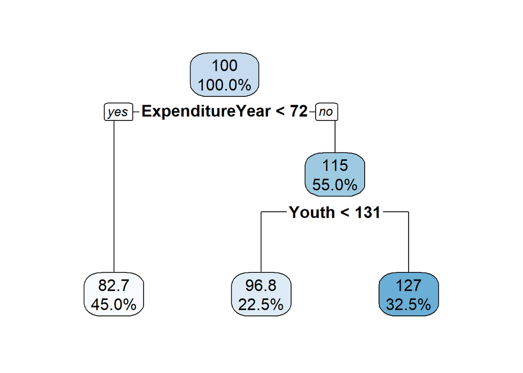

```r
rpart.plot(m.rpart, digits = 3, fallen.leaves = TRUE,tweak=1.3)
```

##6)Were any predictor variables excluded from your model? Why do you think they were excluded (ie how does the rpart function decide which variables to include)? This might take some research to figure out how the function works. #Yes the rpart function removed the variables; Education, StateSize, YouthUnemployment, BelowWages, Males, LabourForce and HighYouthUnemploy. These were likely excluded because they did not play a direct role in altering or influencing crime rates from the important variables which were ExpenditureYear and Youth. It could also be that the removed variables from the plot all play a small role influencing crime rates, but do not directly branch off differences between each other such as the wine example. For example Education may play a role on youth males present affecting crime, but its role is no different than the BelowWage scores and therefore they cannot be on a separate branch further down the regression tree.

##7) Now, let’s use the model developed with the crimedata.csv to predict crime rates 10 years later. Import the crimedata10.csv file into R and use the predict function to predict crime rates give all the predicor variables available in crimedata10.csv. See Red wine example in MyLS for help.

```r
FutureCrime=read.csv("crimedata10.csv")

summary(FutureCrime)
```

```
##      Youth         Education     ExpenditureYear   LabourForce
##  Min.   :120.0   Min.   :10.10   Min.   : 41.00   Min.   :497.0
##  1st Qu.:134.0   1st Qu.:11.55   1st Qu.: 58.50   1st Qu.:538.0
##  Median :139.0   Median :12.40   Median : 73.00   Median :563.0
##  Mean   :140.5   Mean   :12.40   Mean   : 80.23   Mean   :565.5
##  3rd Qu.:151.5   3rd Qu.:13.25   3rd Qu.: 97.00   3rd Qu.:599.0
##  Max.   :164.0   Max.   :15.20   Max.   :157.00   Max.   :641.0
##      Males          MoreMales        StateSize     YouthUnemployment
##  Min.   : 935.0   Min.   :0.0000   Min.   :  3.0   Min.   : 71.00
##  1st Qu.: 969.5   1st Qu.:0.0000   1st Qu.: 11.0   1st Qu.: 82.00
##  Median : 983.0   Median :0.0000   Median : 25.0   Median : 93.00
##  Mean   : 986.9   Mean   :0.2128   Mean   : 37.7   Mean   : 97.45
##  3rd Qu.: 994.0   3rd Qu.:0.0000   3rd Qu.: 43.0   3rd Qu.:108.50
##  Max.   :1079.0   Max.   :1.0000   Max.   :180.0   Max.   :143.00
##  MatureUnemployment HighYouthUnemploy      Wage         BelowWage
##  Min.   :15.00      Min.   :0.0000    Min.   :359.0   Min.   :126.0
##  1st Qu.:28.00      1st Qu.:0.0000    1st Qu.:530.0   1st Qu.:165.0
##  Median :34.00      Median :0.0000    Median :615.0   Median :182.0
##  Mean   :33.36      Mean   :0.4043    Mean   :594.6   Mean   :193.0
##  3rd Qu.:39.00      3rd Qu.:1.0000    3rd Qu.:659.5   3rd Qu.:229.5
##  Max.   :59.00      Max.   :1.0000    Max.   :748.0   Max.   :257.0
##     Southern        CrimeRate
##  Min.   :0.0000   Min.   : 26.50
##  1st Qu.:0.0000   1st Qu.: 76.35
##  Median :0.0000   Median :103.50
##  Mean   :0.3404   Mean   :102.07
##  3rd Qu.:1.0000   3rd Qu.:130.25
##  Max.   :1.0000   Max.   :178.20
```

```r
p.rpartfuture=predict(m.rpart, FutureCrime)
```

##8) Run a pearson correlation test using the cor function to determine how the predicted crime rate correlated with the actual crime rate listed in the crimedata10.csv file. What was the correlation coefficient from this analysis?

```r
cor(p.rpartfuture, FutureCrime[["CrimeRate"]], method="pearson")
```

```
## [1] 0.6726163
```

#This indicates a moderate correlation between the prediction of current and future crime based on our model

##9) Calculate the mean absolute error of your predictions. Do you think our model was very good a predicting crime rates?

```r
MAE <- function(actual, predicted)  {
  mean(abs(actual - predicted))
}

MAE(predicted = p.rpartfuture,actual = FutureCrime[["CrimeRate"]])
```

```
## [1] 24.35485
```

#Since the mean absolute error rate was so high this model does not appear to be very effective at predicting crime rates due to such a large error range.

##10) Using the wine example as a starting point, figure out how to generate a null distribution for comparison with your model results. In other words, if you randomly assign crime rates to states and calculate the absolute error repeatedly, what would be the mean absolute error you would attain. An annotated example is provided in the last code chunk of the red wine example.

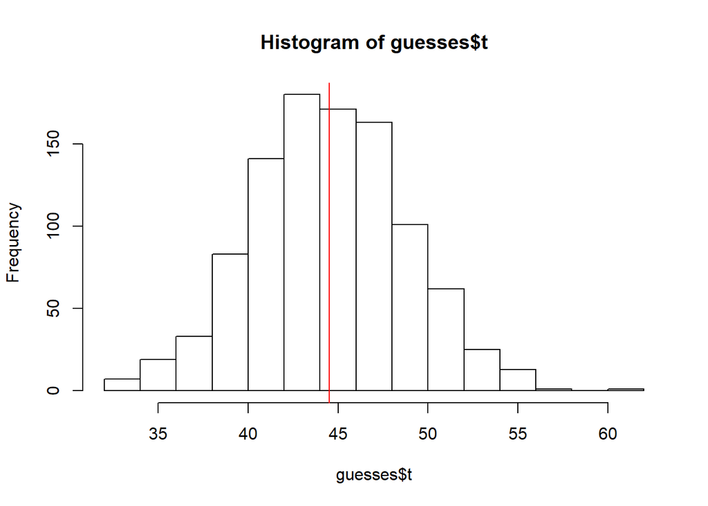

```r
crime.rates.test=FutureCrime[["CrimeRate"]]

actual=crime.rates.test

MAE2 = function(data,indices)  {
  d=data[indices]
  return(mean(abs(actual - d)))
}

library(boot)
guesses=boot(data=crime.rates.test, statistic=MAE2, R=1000)

{hist(guesses$t)
abline(v=mean(guesses$t),col="red")}
```

```r
mean(guesses$t)
```

```
## [1] 44.52606
```

#The null distribution of the model is determined by randomly assign crime rates to states and calculate the absolute error repeatedly, which resulted in a mean absolute error greater than 44 (cannot put an exact decimal place as it will vary with every time that it is run through by randomly assigning crime rates).

##12) Is the mean absolute error from your model significantly different from random chance? Provide the p-value estimated from comparison with your null distribution.

```r
p.value=length(which((guesses$t<24.354)==T))/1000
p.value
```

```
## [1] 0
```